# Scraping Jobs from Indeed.com and Using pandas for manipulation

```python
import requests
from bs4 import BeautifulSoup
import pandas as pd
import seaborn as sns
%matplotlib inline
```

```python
class ScrapIndeedData():

    def __init__(self, job_name, location, max_results=10):
        self.job_name = job_name
        self.location = location
        self.max_results = max_results
        self.URL = "https://www.indeed.com/jobs?q={}+&l={}&start=".format(self.job_name, self.location)
        self.page = [requests.get(self.URL + str(start)) for start in range(0, max_results, 10)]
        self.soup = [BeautifulSoup(p.content, "html.parser") for p in self.page]

    def get_job_title(self, jobs=[]):
        #find all div with class row in each page parsed in self.soup
        divs = [d.find_all(name="div", attrs={"class":"row"}) for d in self.soup]

        #get the title(job title) in each div of each web page.
        jobs = [a["title"] for div in divs  for sub_div in div for a in sub_div.find_all(name="a",attrs={"data-tn-element":"jobTitle"})]

        return(jobs)

    def get_company_name(self, companies_names=[]):
        # get the span that contains the names of the company
        spans = [s.find_all("span", attrs={"class":"company"}) for s in self.soup]
        #extract the company name and take away white spaces on both sides
        companies_names = [s.text.strip() for pg in spans for s in pg ]
        return(companies_names)

    def get_company_location(self, locations = [] ):
        #find all span with class location from each parsed web page
        spans = [s.find_all("span", attrs={"class": "location"}) for s in self.soup]

        #get the text (location) from each each span span extracted above
        locations = [loc.text for span in spans for loc in span]
        return(locations)

    def get_job_links(self, links=[]):
        divs = [div for div in self.soup.find_all(name="div", attrs={"class":"row"})]
        links = ["https:indeed.com"+link.get('href') for d in divs for link in d.find_all(name="a") if link != "#"]#,attrs={"class":"turnstitleLink"})]
        return (links)

    def get_data_frame(self):
        cn = self.get_company_name() #call get_company_name to provide the company names
        jt = self.get_job_title() #call get_jb_title method to provide the job titles
        loc = self.get_company_location() #call get_company_location to provide the company locations


        info = {"Company_Name":pd.Series(cn,index=[i for i in range(1,len(cn) +1)]),
                "Job_Title": pd.Series(jt,index=[i for i in range(1,len(jt) + 1 )]),
                "Location": pd.Series(loc,index=[i for i in range(1,len(loc) +1)])}
        return(pd.DataFrame(info))


test = ScrapIndeedData("data science", "iowa",1000)
```

#### now that the scraper class is all written you can call get_data_frame() to a get a complete DF of the company name, title and location. And perform analysis on it .

For example:

- I will find the city with most jobs in Iowa base on these 750 jobs i scrapped.
- The Company with the most jobs with the same sample
- Do some data manipulation with pandas

```python
df = test.get_data_frame()
# save data to a csv file
df.to_csv("indeedjob.csv")
```

```python
df.head(15)
```

|  | Company_Name | Job_Title | Location |
| --- | --- | --- | --- |
| 1 | Wells Fargo | Research Portfolio Analyst | West Des Moines, IA |
| 2 | Wells Fargo | Analytic Consultant 3 | West Des Moines, IA |
| 3 | InfoWeb Systems, Inc. | Cloud, Data Engineer with Oracle DBA Focus | Des Moines, IA |
| 4 | Workiva Inc. | Data Solutions Analyst | Ames, IA |
| 5 | Wells Fargo | Analytic Consultant 3 | Des Moines, IA |
| 6 | Wells Fargo | Analytic Consultant 4: Team Member Insights St... | West Des Moines, IA |
| 7 | InfoSpace, Inc. | Director, Advanced Analytics | Cedar Rapids, IA |
| 8 | United Fire Group | Database & Application Development Intern | Cedar Rapids, IA |
| 9 | P3 | Data Engineer | West Des Moines, IA |
| 10 | Kuder, Inc. | Junior Software Developer | Adel, IA 50003 |
| 11 | Alliant Energy | Data Scientist | Cedar Rapids, IA |
| 12 | The University of Iowa | DATABASE ARCHITECT | Iowa City, IA 52242 |
| 13 | DuPont | Data Scientist - Soil & Plant Sciences | Johnston, IA |
| 14 | Wells Fargo | Advanced Analytics and Modeling for Home Mortg... | West Des Moines, IA |
| 15 | Predictive Science | Data Scientist | United States |

From peaking at the data you can see that there are some cities with zipcode. I will take the zipcodes from does cities to make it easy to work with.

And also indeed repeats the same job multiple times so i will also drop all rows with the same data.

- To clean the I will find the index where the zipcode starts and subset the location string to that point. And since I know Iowa zip codes start with 5 and does not have numbers in the city names, I will have to find 5

```python
locations = df["Location"].values
tidy_location = [location[:location.find("5")].strip() if location.find("5") != -1 else location  for location in locations]

#assign data back to dataframe
df = df.assign(Location=tidy_location)

#drop duplicated data
df2 = df[:].drop_duplicates()
print("looks clean")
df2.head(15)
```

```
looks clean
```

|  | Company_Name | Job_Title | Location |
| --- | --- | --- | --- |
| 1 | Wells Fargo | Research Portfolio Analyst | West Des Moines, IA |
| 2 | Wells Fargo | Analytic Consultant 3 | West Des Moines, IA |
| 3 | InfoWeb Systems, Inc. | Cloud, Data Engineer with Oracle DBA Focus | Des Moines, IA |
| 4 | Workiva Inc. | Data Solutions Analyst | Ames, IA |
| 5 | Wells Fargo | Analytic Consultant 3 | Des Moines, IA |
| 6 | Wells Fargo | Analytic Consultant 4: Team Member Insights St... | West Des Moines, IA |
| 7 | InfoSpace, Inc. | Director, Advanced Analytics | Cedar Rapids, IA |
| 8 | United Fire Group | Database & Application Development Intern | Cedar Rapids, IA |
| 9 | P3 | Data Engineer | West Des Moines, IA |
| 10 | Kuder, Inc. | Junior Software Developer | Adel, IA |
| 11 | Alliant Energy | Data Scientist | Cedar Rapids, IA |
| 12 | The University of Iowa | DATABASE ARCHITECT | Iowa City, IA |
| 13 | DuPont | Data Scientist - Soil & Plant Sciences | Johnston, IA |
| 14 | Wells Fargo | Advanced Analytics and Modeling for Home Mortg... | West Des Moines, IA |
| 15 | Predictive Science | Data Scientist | United States |

### Top Five cities with the most data science career in Iowa As of 4/23/2017

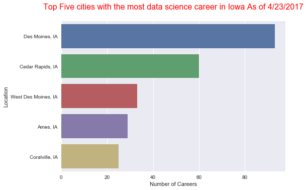

```python
#Count the frequency of a city in the data in decending order and the use head to get the top 5
loc_data = df2["Location"].value_counts(ascending=False).head()
#put loc_data in a data frame
loc_df = pd.DataFrame({"Location":loc_data.index, "Count":loc_data.values})
#plot loc_df (i am using seaborn)
sns.set(style="darkgrid")
sns.plt.title("Top Five cities with the most data science career in Iowa As of 4/23/2017\n",fontsize=16,color="r")
sns.barplot(y = "Location", x ="Count", data=loc_df).set(xlabel="Number of Careers")
```

### Top Five companies with the most career openings in Iowa

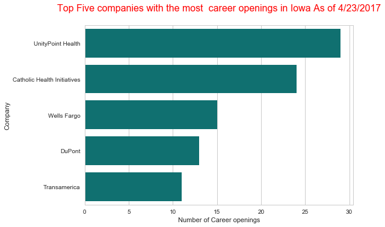

```python
dt = df2["Company_Name"].value_counts(ascending=False).head()
df3 =pd.DataFrame({"Company":dt.index, "Count":dt.values})
sns.set(style="whitegrid")
sns.plt.title("Top Five companies with the most  career openings in Iowa As of 4/23/2017\n",fontsize=16,color="r")
sns.barplot(y = "Company", x ="Count", data=df3, color="teal").set(xlabel="Number of Career openings")
```

## Data Transformation

**I use the head method on all dataFrame to keep the notebook short when I convert to html**

- Filter and Querying
- arrange and sorting
- select
- mutate
- Group and summarizing

## Filter and Querying

**Examples:**

- Find all Job title and Location for only Wells Fargo
- Find Comapany, job title and location but not in West Des Moines and comapnay not Wells fargo

```python
df2.query("Company_Name == 'Wells Fargo'").head()
```

|  | Company_Name | Job_Title | Location |
| --- | --- | --- | --- |
| 1 | Wells Fargo | Research Portfolio Analyst | West Des Moines, IA |
| 2 | Wells Fargo | Analytic Consultant 3 | West Des Moines, IA |
| 5 | Wells Fargo | Analytic Consultant 3 | Des Moines, IA |
| 6 | Wells Fargo | Analytic Consultant 4: Team Member Insights St... | West Des Moines, IA |
| 14 | Wells Fargo | Advanced Analytics and Modeling for Home Mortg... | West Des Moines, IA |

```python
#find locations but not west Des Moines and comapnay not Wells fargo
df2.query("Location != 'West Des Moines, IA'  & Company_Name != 'Wells Fargo'").head()
```

|  | Company_Name | Job_Title | Location |
| --- | --- | --- | --- |
| 3 | InfoWeb Systems, Inc. | Cloud, Data Engineer with Oracle DBA Focus | Des Moines, IA |
| 4 | Workiva Inc. | Data Solutions Analyst | Ames, IA |
| 7 | InfoSpace, Inc. | Director, Advanced Analytics | Cedar Rapids, IA |
| 8 | United Fire Group | Database & Application Development Intern | Cedar Rapids, IA |
| 10 | Kuder, Inc. | Junior Software Developer | Adel, IA |

## Arrange and Sorting

- sort data by company name (arranges in ascending other)
- rename columns

```python
df2.sort_values(["Company_Name"]).head()
```

|  | Company_Name | Job_Title | Location |
| --- | --- | --- | --- |
| 48 | ACT, Inc. | Research Scientist | Iowa City, IA |
| 460 | ACT, Inc. | Lead Solutions Architect | Iowa City, IA |
| 489 | ACT, Inc. | Senior Manager Market Research | Iowa City, IA |
| 27 | ACT, Inc. | Summer Internship: Behavior and Navigation Res... | Iowa City, IA |
| 69 | ACT, Inc. | Investigative Analyst I | Iowa City, IA |

```python
df.rename(columns={"Location":"Locations"}).head()
```

|  | Company_Name | Job_Title | Locations |
| --- | --- | --- | --- |
| 1 | Wells Fargo | Research Portfolio Analyst | West Des Moines, IA |
| 2 | Wells Fargo | Analytic Consultant 3 | West Des Moines, IA |
| 3 | InfoWeb Systems, Inc. | Cloud, Data Engineer with Oracle DBA Focus | Des Moines, IA |
| 4 | Workiva Inc. | Data Solutions Analyst | Ames, IA |
| 5 | Wells Fargo | Analytic Consultant 3 | Des Moines, IA |

## Selection

- Select data of just the Company names
- Select the Locations and Job title only

```python
df2['Company_Name'].head()
```

```
1              Wells Fargo
2              Wells Fargo
3    InfoWeb Systems, Inc.
4             Workiva Inc.
5              Wells Fargo
Name: Company_Name, dtype: object
```

Assuming I dont mind the company I want to work and I only care about the location and Job title

```python
## select multiple columns in different order
# this retrieves a column with the names specified in the list
df2[["Location","Job_Title"]].head()
```

|  | Location | Job_Title |
| --- | --- | --- |
| 1 | West Des Moines, IA | Research Portfolio Analyst |
| 2 | West Des Moines, IA | Analytic Consultant 3 |
| 3 | Des Moines, IA | Cloud, Data Engineer with Oracle DBA Focus |
| 4 | Ames, IA | Data Solutions Analyst |
| 5 | Des Moines, IA | Analytic Consultant 3 |

Select comapnay_names without duplicate to know the number of unique companies hiring

```python
#Select comapnay_names without duplicate to know the number of unique companies hiring
print("Number of companies hiring:", df2[["Company_Name"]].drop_duplicates().size) # get the nuber

# we can do same for Job_title
print("Number of Job roles hiring for:",df2[["Job_Title"]].drop_duplicates().size)

# view the companies names
print(df2[["Company_Name"]].drop_duplicates().head())
```

```
Number of companies hiring: 194
Number of Job roles hiring for: 386
            Company_Name
1            Wells Fargo
3  InfoWeb Systems, Inc.
4           Workiva Inc.
7        InfoSpace, Inc.
8      United Fire Group
```

**From the numbers above we can confidently say that, they is at least some company hiring for more one position.**(it could be the same position but different location)

Actually we saw that in the visualization above.

## Mutate / Assign

For this part i will make the pay up just to illustrate how **assign**(behaves like mutate in R) works

**Note:** DataFrame.assign will not change the original DataFram unless you assign it back to the same variable

```python
# will make up pay for each job
df2.assign(pay=df2.index * 58 / 5).head()
```

|  | Company_Name | Job_Title | Location | pay |
| --- | --- | --- | --- | --- |
| 1 | Wells Fargo | Research Portfolio Analyst | West Des Moines, IA | 11.6 |
| 2 | Wells Fargo | Analytic Consultant 3 | West Des Moines, IA | 23.2 |
| 3 | InfoWeb Systems, Inc. | Cloud, Data Engineer with Oracle DBA Focus | Des Moines, IA | 34.8 |
| 4 | Workiva Inc. | Data Solutions Analyst | Ames, IA | 46.4 |
| 5 | Wells Fargo | Analytic Consultant 3 | Des Moines, IA | 58.0 |

```python
#checking if I lied :)
df2.head()
```

|  | Company_Name | Job_Title | Location |
| --- | --- | --- | --- |
| 1 | Wells Fargo | Research Portfolio Analyst | West Des Moines, IA |
| 2 | Wells Fargo | Analytic Consultant 3 | West Des Moines, IA |
| 3 | InfoWeb Systems, Inc. | Cloud, Data Engineer with Oracle DBA Focus | Des Moines, IA |
| 4 | Workiva Inc. | Data Solutions Analyst | Ames, IA |
| 5 | Wells Fargo | Analytic Consultant 3 | Des Moines, IA |

## Grouping and Summarizing

companies and number of job in decending order

```python
#companies and number of job in decending order
df2.groupby(["Company_Name"],sort=False).count().sort_values(by=["Job_Title"],ascending=False).head()
```

| Company_Name | Job_Title | Location |
| --- | --- | --- |
| UnityPoint Health | 29 | 29 |
| Catholic Health Initiatives | 24 | 24 |
| Wells Fargo | 15 | 15 |
| DuPont | 13 | 13 |
| Integrated DNA Technologies, Inc | 11 | 11 |

Note that we can do this without grouping. we can just use values_count

```python
(df2["Company_Name"].value_counts(ascending=False).head())
```

```
UnityPoint Health              29
Catholic Health Initiatives    24
Wells Fargo                    15
DuPont                         13
Transamerica                   11
Name: Company_Name, dtype: int64
```

Differnce between the two is one is a data frame and gives all the colunms and the second is a Series

**Summary of the whole data set**

```python
df2.describe()
```

|  | Company_Name | Job_Title | Location |
| --- | --- | --- | --- |
| count | 415 | 415 | 415 |
| unique | 194 | 386 | 71 |
| top | UnityPoint Health | Software Developer | Des Moines, IA |
| freq | 29 | 5 | 93 |

Thank you for checking it out. If you see anything wrong or could be done better, faster or shorter , please let me know through any of my contact information which can be found on **[my page](http://isaactetteh.herokuapp.com/)**